# Intro to the tidyverse: `dplyr`-verbs, Piping & Exploration

Welcome to the follow-up to the “Intro to R”! If you see this you have managed to download the files from GitHub, which already makes you smarter than tolly500:

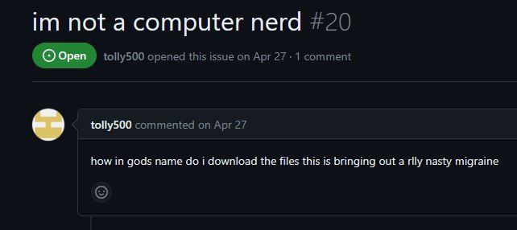

This means now it’s…

# Setup time

[figure not shown]

If you haven’t already:

1. Install R:
- [Windows](https://cran.r-project.org/bin/windows/base/)
- [MacOS](https://cran.r-project.org/bin/macosx/) (make sure you select the right one based on whether you have an “old” intel mac or a new Apple silicon (M1/M2) mac)
- Linux: from package manager (probably either `R` or `r-base`)
2. Install RStudio [from the official website](https://posit.co/download/rstudio-desktop/) (please)
3. Install packages:
- once you are inside RStudio, head to the console (the little window that says “console”), enter `install.packages(c("tidyverse", "gapminder", "here", "markdown", "rmarkdown"))` and hit Enter.
- Enjoy epic hacker moment
- *Note:* Once you have installed packages, you don’t need to install them again! Just load them with `library()`. So please, don’t include `install.packages()` in your code! Ever!
4. Make yourself feel at home: If you’re done early, under Tools > Global Options > Appearance you can change the theme etc

# `dplyr`-verbs

```r
library(dplyr)
```

`dplyr` is a grammar for data manipulation. It follows the logic of “verbs”:

- `select()` allows you to pick variables by name
- `filter()` picks cases based on their values
- `mutate()` change existing or add new variables
- `arrange()` changes the ordering of rows
- `summarise()` reduces multiple values down to a single value

[Click here](https://dplyr.tidyverse.org/) to get to the `dplyr`-documentation, which is really comprehensive with many examples!

We will use data from [Gapminder](https://www.gapminder.org/) for our examples, which is provided as an R-package:

```r
library(gapminder)
data("gapminder")
```

**Selecting:**

Let’s find out together how `select()` works:

```r
?select # or: help(select)
```

R has great built-in documentation you can *always* use to look things up if you don’t remember something or want to learn something new.

```r
select(gapminder, country, year, lifeExp)
```

```
#> # A tibble: 1,704 × 3
#>    country      year lifeExp
#>    <fct>       <int>   <dbl>
#>  1 Afghanistan  1952    28.8
#>  2 Afghanistan  1957    30.3
#>  3 Afghanistan  1962    32.0
#>  4 Afghanistan  1967    34.0
#>  5 Afghanistan  1972    36.1
#>  6 Afghanistan  1977    38.4
#>  7 Afghanistan  1982    39.9
#>  8 Afghanistan  1987    40.8
#>  9 Afghanistan  1992    41.7
#> 10 Afghanistan  1997    41.8
#> # ℹ 1,694 more rows
```

But for `dplyr`-verbs, the data is always the first argument, so we can “pipe”:

```r
gapminder |> select(country, year, lifeExp)
```

```
#> # A tibble: 1,704 × 3
#>    country      year lifeExp
#>    <fct>       <int>   <dbl>
#>  1 Afghanistan  1952    28.8
#>  2 Afghanistan  1957    30.3
#>  3 Afghanistan  1962    32.0
#>  4 Afghanistan  1967    34.0
#>  5 Afghanistan  1972    36.1
#>  6 Afghanistan  1977    38.4
#>  7 Afghanistan  1982    39.9
#>  8 Afghanistan  1987    40.8
#>  9 Afghanistan  1992    41.7
#> 10 Afghanistan  1997    41.8
#> # ℹ 1,694 more rows
```

```r
gapminder |> select(-c(continent, pop))
```

```
#> # A tibble: 1,704 × 4
#>    country      year lifeExp gdpPercap
#>    <fct>       <int>   <dbl>     <dbl>
#>  1 Afghanistan  1952    28.8      779.
#>  2 Afghanistan  1957    30.3      821.
#>  3 Afghanistan  1962    32.0      853.
#>  4 Afghanistan  1967    34.0      836.
#>  5 Afghanistan  1972    36.1      740.
#>  6 Afghanistan  1977    38.4      786.
#>  7 Afghanistan  1982    39.9      978.
#>  8 Afghanistan  1987    40.8      852.
#>  9 Afghanistan  1992    41.7      649.
#> 10 Afghanistan  1997    41.8      635.
#> # ℹ 1,694 more rows
```

```r
gapminder |> select(starts_with("c"))
```

```
#> # A tibble: 1,704 × 2
#>    country     continent
#>    <fct>       <fct>
#>  1 Afghanistan Asia
#>  2 Afghanistan Asia
#>  3 Afghanistan Asia
#>  4 Afghanistan Asia
#>  5 Afghanistan Asia
#>  6 Afghanistan Asia
#>  7 Afghanistan Asia
#>  8 Afghanistan Asia
#>  9 Afghanistan Asia
#> 10 Afghanistan Asia
#> # ℹ 1,694 more rows
```

The “pipe” (`|>` or `%>%`) takes what is one the left side, and hands it to the function on the right-hand side as the first argument. Sounds complicated? Just read the pipe in your head as “and then…”. So: Take `gapminder` *and then* `select()` the columns.

You can also select `everything()`, which selects… well, everything, kind of. You can use it e.g. to reorder columns (here, it will select those explicitly called upon first, and then `everything()` else):

```r
gapminder |> select(pop, gdpPercap, everything())
```

```
#> # A tibble: 1,704 × 6
#>         pop gdpPercap country     continent  year lifeExp
#>       <int>     <dbl> <fct>       <fct>     <int>   <dbl>
#>  1  8425333      779. Afghanistan Asia       1952    28.8
#>  2  9240934      821. Afghanistan Asia       1957    30.3
#>  3 10267083      853. Afghanistan Asia       1962    32.0
#>  4 11537966      836. Afghanistan Asia       1967    34.0
#>  5 13079460      740. Afghanistan Asia       1972    36.1
#>  6 14880372      786. Afghanistan Asia       1977    38.4
#>  7 12881816      978. Afghanistan Asia       1982    39.9
#>  8 13867957      852. Afghanistan Asia       1987    40.8
#>  9 16317921      649. Afghanistan Asia       1992    41.7
#> 10 22227415      635. Afghanistan Asia       1997    41.8
#> # ℹ 1,694 more rows
```

**Filtering:** Subset your data!

```r
gapminder |> filter(continent == "Asia")
```

```
#> # A tibble: 396 × 6
#>    country     continent  year lifeExp      pop gdpPercap
#>    <fct>       <fct>     <int>   <dbl>    <int>     <dbl>
#>  1 Afghanistan Asia       1952    28.8  8425333      779.
#>  2 Afghanistan Asia       1957    30.3  9240934      821.
#>  3 Afghanistan Asia       1962    32.0 10267083      853.
#>  4 Afghanistan Asia       1967    34.0 11537966      836.
#>  5 Afghanistan Asia       1972    36.1 13079460      740.
#>  6 Afghanistan Asia       1977    38.4 14880372      786.
#>  7 Afghanistan Asia       1982    39.9 12881816      978.
#>  8 Afghanistan Asia       1987    40.8 13867957      852.
#>  9 Afghanistan Asia       1992    41.7 16317921      649.
#> 10 Afghanistan Asia       1997    41.8 22227415      635.
#> # ℹ 386 more rows
```

```r
gapminder |> filter(year == 2007)
```

```
#> # A tibble: 142 × 6
#>    country     continent  year lifeExp       pop gdpPercap
#>    <fct>       <fct>     <int>   <dbl>     <int>     <dbl>
#>  1 Afghanistan Asia       2007    43.8  31889923      975.
#>  2 Albania     Europe     2007    76.4   3600523     5937.
#>  3 Algeria     Africa     2007    72.3  33333216     6223.
#>  4 Angola      Africa     2007    42.7  12420476     4797.
#>  5 Argentina   Americas   2007    75.3  40301927    12779.
#>  6 Australia   Oceania    2007    81.2  20434176    34435.
#>  7 Austria     Europe     2007    79.8   8199783    36126.
#>  8 Bahrain     Asia       2007    75.6    708573    29796.
#>  9 Bangladesh  Asia       2007    64.1 150448339     1391.
#> 10 Belgium     Europe     2007    79.4  10392226    33693.
#> # ℹ 132 more rows
```

```r
gapminder |>
  filter(year == 2007 & continent %in% c("Asia", "Europe") & pop > 1e7)
```

```
#> # A tibble: 37 × 6
#>    country        continent  year lifeExp        pop gdpPercap
#>    <fct>          <fct>     <int>   <dbl>      <int>     <dbl>
#>  1 Afghanistan    Asia       2007    43.8   31889923      975.
#>  2 Bangladesh     Asia       2007    64.1  150448339     1391.
#>  3 Belgium        Europe     2007    79.4   10392226    33693.
#>  4 Cambodia       Asia       2007    59.7   14131858     1714.
#>  5 China          Asia       2007    73.0 1318683096     4959.
#>  6 Czech Republic Europe     2007    76.5   10228744    22833.
#>  7 France         Europe     2007    80.7   61083916    30470.
#>  8 Germany        Europe     2007    79.4   82400996    32170.
#>  9 Greece         Europe     2007    79.5   10706290    27538.
#> 10 India          Asia       2007    64.7 1110396331     2452.
#> # ℹ 27 more rows
```

With the pipe, we can also combine these steps easily:

```r
gapminder |>
  filter(continent == "Europe" & year == 2007) |>
  select(country, lifeExp, gdpPercap)
```

```
#> # A tibble: 30 × 3
#>    country                lifeExp gdpPercap
#>    <fct>                    <dbl>     <dbl>
#>  1 Albania                   76.4     5937.
#>  2 Austria                   79.8    36126.
#>  3 Belgium                   79.4    33693.
#>  4 Bosnia and Herzegovina    74.9     7446.
#>  5 Bulgaria                  73.0    10681.
#>  6 Croatia                   75.7    14619.
#>  7 Czech Republic            76.5    22833.
#>  8 Denmark                   78.3    35278.
#>  9 Finland                   79.3    33207.
#> 10 France                    80.7    30470.
#> # ℹ 20 more rows
```

Think: take `gapminder` *and then* `filter()` it *and then* `select()` these columns.

**Arranging:**

```r
gapminder |> arrange(lifeExp)
```

```
#> # A tibble: 1,704 × 6
#>    country      continent  year lifeExp     pop gdpPercap
#>    <fct>        <fct>     <int>   <dbl>   <int>     <dbl>
#>  1 Rwanda       Africa     1992    23.6 7290203      737.
#>  2 Afghanistan  Asia       1952    28.8 8425333      779.
#>  3 Gambia       Africa     1952    30    284320      485.
#>  4 Angola       Africa     1952    30.0 4232095     3521.
#>  5 Sierra Leone Africa     1952    30.3 2143249      880.
#>  6 Afghanistan  Asia       1957    30.3 9240934      821.
#>  7 Cambodia     Asia       1977    31.2 6978607      525.
#>  8 Mozambique   Africa     1952    31.3 6446316      469.
#>  9 Sierra Leone Africa     1957    31.6 2295678     1004.
#> 10 Burkina Faso Africa     1952    32.0 4469979      543.
#> # ℹ 1,694 more rows
```

```r
gapminder |> arrange(desc(pop))
```

```
#> # A tibble: 1,704 × 6
#>    country continent  year lifeExp        pop gdpPercap
#>    <fct>   <fct>     <int>   <dbl>      <int>     <dbl>
#>  1 China   Asia       2007    73.0 1318683096     4959.
#>  2 China   Asia       2002    72.0 1280400000     3119.
#>  3 China   Asia       1997    70.4 1230075000     2289.
#>  4 China   Asia       1992    68.7 1164970000     1656.
#>  5 India   Asia       2007    64.7 1110396331     2452.
#>  6 China   Asia       1987    67.3 1084035000     1379.
#>  7 India   Asia       2002    62.9 1034172547     1747.
#>  8 China   Asia       1982    65.5 1000281000      962.
#>  9 India   Asia       1997    61.8  959000000     1459.
#> 10 China   Asia       1977    64.0  943455000      741.
#> # ℹ 1,694 more rows
```

Again, combining what we know to find the countries with the highest life expectancy:

```r
gapminder |>
  filter(continent == "Europe" & year == 2007) |>
  select(country, lifeExp, gdpPercap) |>
  arrange(desc(lifeExp))
```

```
#> # A tibble: 30 × 3
#>    country     lifeExp gdpPercap
#>    <fct>         <dbl>     <dbl>
#>  1 Iceland        81.8    36181.
#>  2 Switzerland    81.7    37506.
#>  3 Spain          80.9    28821.
#>  4 Sweden         80.9    33860.
#>  5 France         80.7    30470.
#>  6 Italy          80.5    28570.
#>  7 Norway         80.2    49357.
#>  8 Austria        79.8    36126.
#>  9 Netherlands    79.8    36798.
#> 10 Greece         79.5    27538.
#> # ℹ 20 more rows
```

*Think for a moment: how do you read this sequence in your head?*

**Renaming:**

```r
gapminder |>
  select(country, year, lifeExp, gdpPercap) |>
  rename("life_exp" = lifeExp, "gdp_pc" = gdpPercap)
```

```
#> # A tibble: 1,704 × 4
#>    country      year life_exp gdp_pc
#>    <fct>       <int>    <dbl>  <dbl>
#>  1 Afghanistan  1952     28.8   779.
#>  2 Afghanistan  1957     30.3   821.
#>  3 Afghanistan  1962     32.0   853.
#>  4 Afghanistan  1967     34.0   836.
#>  5 Afghanistan  1972     36.1   740.
#>  6 Afghanistan  1977     38.4   786.
#>  7 Afghanistan  1982     39.9   978.
#>  8 Afghanistan  1987     40.8   852.
#>  9 Afghanistan  1992     41.7   649.
#> 10 Afghanistan  1997     41.8   635.
#> # ℹ 1,694 more rows
```

Most of this is self-explanatory right? Here is a tip: you can rename inside `select()`, so you rarely need `rename()`:

```r
gapminder |>
  select(country, year, "life_exp" = lifeExp, "gdp_pc" = gdpPercap)
```

```
#> # A tibble: 1,704 × 4
#>    country      year life_exp gdp_pc
#>    <fct>       <int>    <dbl>  <dbl>
#>  1 Afghanistan  1952     28.8   779.
#>  2 Afghanistan  1957     30.3   821.
#>  3 Afghanistan  1962     32.0   853.
#>  4 Afghanistan  1967     34.0   836.
#>  5 Afghanistan  1972     36.1   740.
#>  6 Afghanistan  1977     38.4   786.
#>  7 Afghanistan  1982     39.9   978.
#>  8 Afghanistan  1987     40.8   852.
#>  9 Afghanistan  1992     41.7   649.
#> 10 Afghanistan  1997     41.8   635.
#> # ℹ 1,694 more rows
```

**Summarising:**

```r
gapminder |>
  filter(year == 2007) |>
  summarise(mean_life_exp = mean(lifeExp, na.rm = TRUE))
```

```
#> # A tibble: 1 × 1
#>   mean_life_exp
#>           <dbl>
#> 1          67.0
```

```r
# Why not `mean()`? E.g. for grouped operations:

gapminder |>
  group_by(continent) |>
  summarise(mean_life_exp = mean(lifeExp, na.rm = TRUE)) |>
  arrange(desc(mean_life_exp))
```

```
#> # A tibble: 5 × 2
#>   continent mean_life_exp
#>   <fct>             <dbl>
#> 1 Oceania            74.3
#> 2 Europe             71.9
#> 3 Americas           64.7
#> 4 Asia               60.1
#> 5 Africa             48.9
```

**Mutating:** Add new or overwrite existing variables:

```r
gapminder |> mutate(pop_million = pop / 1e6)
```

```
#> # A tibble: 1,704 × 7
#>    country     continent  year lifeExp      pop gdpPercap pop_million
#>    <fct>       <fct>     <int>   <dbl>    <int>     <dbl>       <dbl>
#>  1 Afghanistan Asia       1952    28.8  8425333      779.        8.43
#>  2 Afghanistan Asia       1957    30.3  9240934      821.        9.24
#>  3 Afghanistan Asia       1962    32.0 10267083      853.       10.3
#>  4 Afghanistan Asia       1967    34.0 11537966      836.       11.5
#>  5 Afghanistan Asia       1972    36.1 13079460      740.       13.1
#>  6 Afghanistan Asia       1977    38.4 14880372      786.       14.9
#>  7 Afghanistan Asia       1982    39.9 12881816      978.       12.9
#>  8 Afghanistan Asia       1987    40.8 13867957      852.       13.9
#>  9 Afghanistan Asia       1992    41.7 16317921      649.       16.3
#> 10 Afghanistan Asia       1997    41.8 22227415      635.       22.2
#> # ℹ 1,694 more rows
```

```r
gapminder |>
  mutate(
    pop_million = pop / 1e6,
    gdp = gdpPercap * pop
  )
```

```
#> # A tibble: 1,704 × 8
#>    country     continent  year lifeExp      pop gdpPercap pop_million        gdp
#>    <fct>       <fct>     <int>   <dbl>    <int>     <dbl>       <dbl>      <dbl>
#>  1 Afghanistan Asia       1952    28.8  8425333      779.        8.43    6.57e 9
#>  2 Afghanistan Asia       1957    30.3  9240934      821.        9.24    7.59e 9
#>  3 Afghanistan Asia       1962    32.0 10267083      853.       10.3     8.76e 9
#>  4 Afghanistan Asia       1967    34.0 11537966      836.       11.5     9.65e 9
#>  5 Afghanistan Asia       1972    36.1 13079460      740.       13.1     9.68e 9
#>  6 Afghanistan Asia       1977    38.4 14880372      786.       14.9     1.17e10
#>  7 Afghanistan Asia       1982    39.9 12881816      978.       12.9     1.26e10
#>  8 Afghanistan Asia       1987    40.8 13867957      852.       13.9     1.18e10
#>  9 Afghanistan Asia       1992    41.7 16317921      649.       16.3     1.06e10
#> 10 Afghanistan Asia       1997    41.8 22227415      635.       22.2     1.41e10
#> # ℹ 1,694 more rows
```

Other useful stuff:

```r
# count()

gapminder |>
  filter(year == 2007) |>
  count(continent) |>
  arrange(desc(n))
```

```
#> # A tibble: 5 × 2
#>   continent     n
#>   <fct>     <int>
#> 1 Africa       52
#> 2 Asia         33
#> 3 Europe       30
#> 4 Americas     25
#> 5 Oceania       2
```

```r
# n()

gapminder |>
  filter(year == 2007) |>
  group_by(continent) |>
  summarise(N = n(), mean_life_exp = mean(lifeExp, na.rm = TRUE))
```

```
#> # A tibble: 5 × 3
#>   continent     N mean_life_exp
#>   <fct>     <int>         <dbl>
#> 1 Africa       52          54.8
#> 2 Americas     25          73.6
#> 3 Asia         33          70.7
#> 4 Europe       30          77.6
#> 5 Oceania       2          80.7
```

For `group_by()`, if you continue your pipeline after `summarise()` or whatever you did *by group*, you may need to `ungroup()` (otherwise *everything* will be done by group). If you want to `arrange()` your grouped data, you may need to set `.by_group = TRUE` inside of `arrange()`.

If there is *one* thing to remember from this course, it’s the `dplyr`-verbs, because they make data manipulation & exploration really easy. They are building blocks with which you can do most operations you will *ever* need for processing your data.

**Exercise Time:**

1. What countries were Top 10 in life expectancy (`lifeExp`) in 1952? Which were the top 10 in 2007? What changes do you see (in terms of countries and in terms of life expectancy)?
2. Compute overall by continent:
1. Mean life expectancy
2. mean GDP per capita
3. Add a new variable to the `gapminder` data set: Total GDP in billion USD (we can assume that GDP = `gdpPercap` $\times$ `pop`). *Bonus:* In 2007, which countries had the highest total GDP?

```r
# Your code here...
```